# Biostat 203B Homework 4

Due Mar 18 @ 11:59PM

Yuhang Qian

Load database libraries and the tidyverse frontend:

```r
suppressPackageStartupMessages(library(tidyverse))
suppressPackageStartupMessages(library(lubridate))
suppressPackageStartupMessages(library(miceRanger))
```

## Q1. Missing data

Through the Shiny app developed in HW3, we observe abundant missing values in the MIMIC-IV ICU cohort we created. In this question, we use multiple imputation to obtain a data set without missing values.

0. Read following tutorials on the R package miceRanger for imputation: https://github.com/farrellday/miceRanger, https://cran.r-project.org/web/packages/miceRanger/vignettes/miceAlgorithm.html.

   A more thorough book treatment of the practical imputation strategies is the book [*Flexible Imputation of Missing Data*](https://stefvanbuuren.name/fimd/) by Stef van Buuren.
1. Explain the jargon MCAR, MAR, and MNAR.

*MCAR, missing completely at random, the missing data are unrelated to the study variables: thus, the participants with completely observed data are in effect a random sample of all the participants assigned a particular intervention.*

*MAR, missing at random, whether or not data are missing may depend on the values of the observed study variables. However, after conditioning on this information, whether or not data are missing does not depend on the values of the missing data.*

*MNAR, missing not at random, whether or not data are missing depends on the values of the missing data.*

2. Explain in a couple of sentences how the Multiple Imputation by Chained Equations (MICE) work.

*MICE is a multiple imputation method used to replace missing data values in a data set under certain assumptions about the data missingness mechanism (e.g. MAR). Consider an imputation strategy that moves from variable to variable, treating each as a separate missing data problem: Specify a prediction equation of an appropriate form (e.g. linear, binary, etc) for each variable in turn; Randomly draw from the conditional distribution specified by the regression model; Replace previously imputed values with new draws; Iterate for a predetermined number of cycles.*

3. Perform a data quality check of the ICU stays data. Discard variables with substantial missingness, say >5000 `NA`s. Replace apparent data entry errors by `NA`s.

```r
library(tidyverse)

# Load the dataset
icu_cohort <- readRDS("../hw3/mimiciv_shiny/icu_cohort.rds") %>%
  print(width = Inf)
```

```
## # A tibble: 53,150 × 43
##    subject_id intime               hadm_id  stay_id first_careunit
##         <int> <dttm>                 <int>    <int> <chr>
##  1   12776735 2200-07-12 00:33:00 20817525 34547665 Neuro Stepdown
##  2   16256226 2150-12-20 16:09:08 20013290 39289362 Neuro Stepdown
##  3   12974563 2138-11-13 23:30:01 29618057 32563675 Neuro Stepdown
##  4   14609218 2174-06-28 21:13:00 20606189 34947848 Neuro Stepdown
##  5   12687112 2162-05-31 18:08:45 26132667 37445058 Neuro Stepdown
##  6   18190935 2115-11-12 23:23:32 21137829 34338402 Neuro Stepdown
##  7   10404210 2161-03-03 18:30:00 22880512 30254828 Neuro Stepdown
##  8   12552973 2135-09-21 18:12:03 21320643 30261549 Neuro Stepdown
##  9   14303051 2175-11-20 01:02:00 26559537 30401486 Neuro Stepdown
## 10   12347959 2140-07-11 17:54:14 22779073 30503984 Neuro Stepdown
##    last_careunit  outtime               los admittime
##    <chr>          <dttm>              <dbl> <dttm>
```

[output cut: 95 more lines]

```r
# Discard variables with >5000 NAs
icu_cohort_clean <- icu_cohort[, which(colSums(is.na(icu_cohort)) <= 5000)] %>%
  print(width = Inf)
```

```
## # A tibble: 53,150 × 39
##    subject_id intime               hadm_id  stay_id first_careunit
##         <int> <dttm>                 <int>    <int> <chr>
##  1   12776735 2200-07-12 00:33:00 20817525 34547665 Neuro Stepdown
##  2   16256226 2150-12-20 16:09:08 20013290 39289362 Neuro Stepdown
##  3   12974563 2138-11-13 23:30:01 29618057 32563675 Neuro Stepdown
##  4   14609218 2174-06-28 21:13:00 20606189 34947848 Neuro Stepdown
##  5   12687112 2162-05-31 18:08:45 26132667 37445058 Neuro Stepdown
##  6   18190935 2115-11-12 23:23:32 21137829 34338402 Neuro Stepdown
##  7   10404210 2161-03-03 18:30:00 22880512 30254828 Neuro Stepdown
##  8   12552973 2135-09-21 18:12:03 21320643 30261549 Neuro Stepdown
##  9   14303051 2175-11-20 01:02:00 26559537 30401486 Neuro Stepdown
## 10   12347959 2140-07-11 17:54:14 22779073 30503984 Neuro Stepdown
##    last_careunit  outtime               los admittime
##    <chr>          <dttm>              <dbl> <dttm>
```

[output cut: 83 more lines]

```r
# Replace outliers with NAs (outside of fences considered as outliers)
lab_vital_vars <- c("calcium", "magnesium", "potassium", "chloride",
                    "sodium", "creatinine", "bicarbonate", "glucose",
                    "hematocrit", "wbc", "meanbp", "sbp", "temp",
                    "resp_rate", "heartrate")

outlier_replace <- function(x){
  if (is.numeric(x)){
    p25 <- quantile(x, probs = c(.25), na.rm=T)
    p75 <- quantile(x, probs = c(.75), na.rm=T)
    IQR <- p75 - p25
    x <- ifelse(x > p75 + 1.5 * IQR | x < p25 - 1.5 * IQR , NA, x)
  }
}

lab_vital <- select(icu_cohort_clean, all_of(lab_vital_vars))
lab_vital <- apply(lab_vital, 2, outlier_replace)
icu_cohort_clean[, colnames(lab_vital)] <- lab_vital
```

4. Impute missing values by `miceRanger` (request $m=3$ data sets). This step is computational intensive. Make sure to save the imputation results as a file. Hint: Setting `max.depth=10` in the `miceRanger` function may cut some computing time.

```r
library(miceRanger)

system.time(icu_cohort_mice <- miceRanger(
  icu_cohort_clean, m = 3,
  maxiter = 10,
  returnModels = FALSE,
  verbose = FALSE,
  max.depth = 10
  ))
```

```
##      user    system   elapsed
## 57497.065    52.881 13579.251
```

5. Make imputation diagnostic plots and explain what they mean.

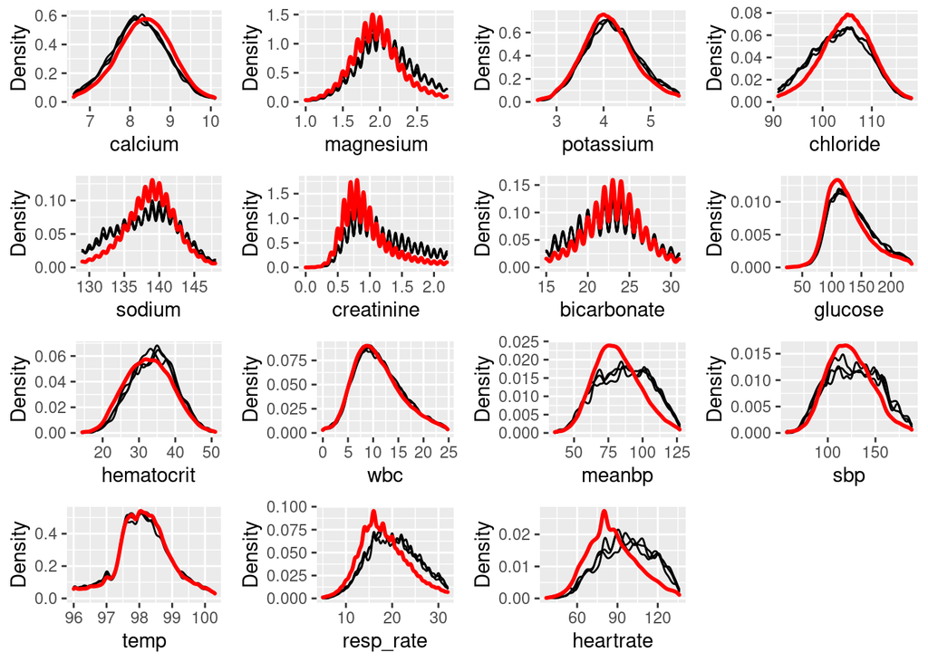

```r
# Distribution of Imputed Values
# For continuous variables, all lab or vital variables have missing values
# For categorical variables, discharge location and marital status have missing values
cat_vars <- c("discharge_location", "marital_status")
plotDistributions(icu_cohort_mice, vars = lab_vital_vars)
```

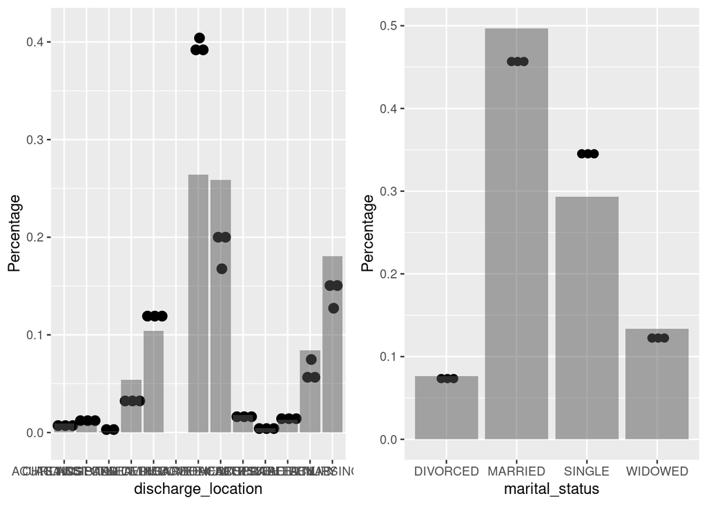

```r
plotDistributions(icu_cohort_mice, vars = cat_vars)
```

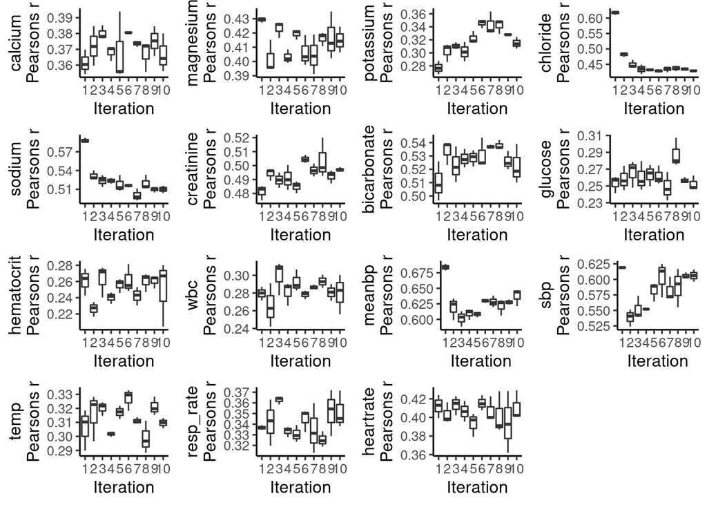

```r
# Convergence of Correlation
plotCorrelations(icu_cohort_mice, vars = lab_vital_vars)
```

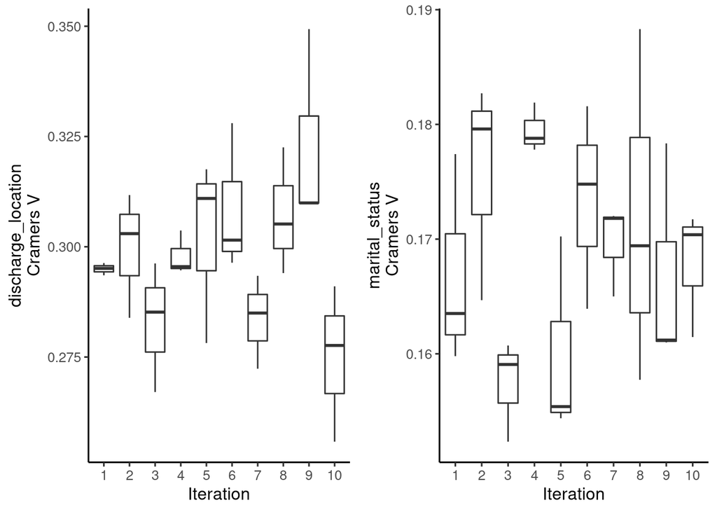

```r
plotCorrelations(icu_cohort_mice, vars = cat_vars)
```

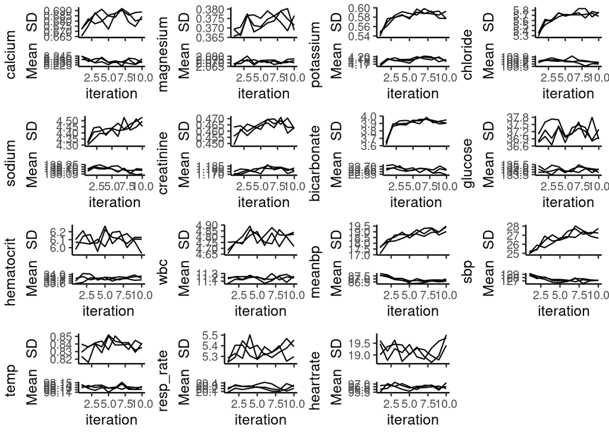

```r
# Center and Dispersion Convergence
plotVarConvergence(icu_cohort_mice, vars = lab_vital_vars)
```

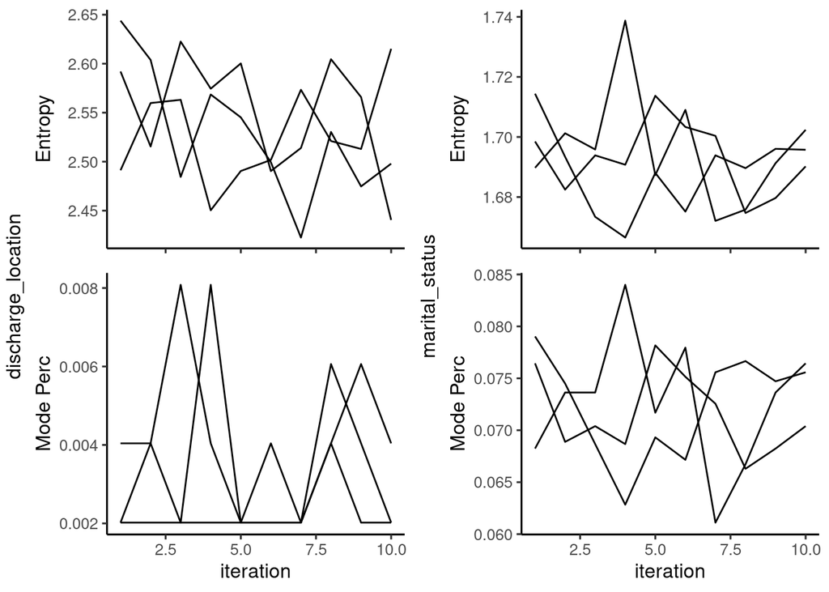

```r
plotVarConvergence(icu_cohort_mice, vars = cat_vars)
```

6. Choose one of the imputed data sets to be used in Q2. This is **not** a good idea to use just one imputed data set or to average multiple imputed data sets. Explain in a couple of sentences what the correct Multiple Imputation strategy is.

```r
# Return the imputed data
icu_mice_datalist <- completeData(icu_cohort_mice)
icu_data1 <- as.data.frame(icu_mice_datalist[1])
colnames(icu_data1) <- colnames(icu_cohort_clean)
icu_data2 <- as.data.frame(icu_mice_datalist[2])
colnames(icu_data2) <- colnames(icu_cohort_clean)
icu_data3 <- as.data.frame(icu_mice_datalist[3])
colnames(icu_data3) <- colnames(icu_cohort_clean)

# In question2, I would use the 1st imputed dataset
# And I would save it in the hw4 folder
icu_data1 %>% saveRDS(paste0("/home/yuhang886688/biostat-203b-2022-winter",
                             "/hw4/icu_imputed.rds"))
```

*The correct Imputation strategy is to run the models in each imputed dataset and then combine or average the results, and get the appropriate standard error (combination of average variance within imputations and variance across imputation).*

## Q2. Predicting 30-day mortality

Develop at least two analytic approaches for predicting the 30-day mortality of patients admitted to ICU using demographic information (gender, age, marital status, ethnicity), first lab measurements during ICU stay, and first vital measurements during ICU stay. For example, you can use (1) logistic regression (`glm()` function in base R or keras), (2) logistic regression with lasso penalty (glmnet or keras package), (3) random forest (randomForest package), or (4) neural network (keras package).

1. Partition data into 80% training set and 20% test set. Stratify partitioning according the 30-day mortality status.

```r
icu_imputed <- readRDS(paste0("/home/yuhang886688/biostat-203b-2022-winter",
                              "/hw4/icu_imputed.rds"))
# Stratify by the 30-day mortality status
icu_imputed_30die <- icu_imputed %>% filter(thirty_day_mort == 1)
icu_imputed_nodie <- icu_imputed %>% filter(thirty_day_mort == 0)

# For people who die within 30 days
sample_30die <- sample(1:nrow(icu_imputed_30die),
                       size = 0.8*nrow(icu_imputed_30die))
training_30die <- icu_imputed_30die[sample_30die, ]
test_30die <- icu_imputed_30die[-sample_30die, ]

# For people who do not die within 30 days
sample_nodie <- sample(1:nrow(icu_imputed_nodie),
                       size=0.8*nrow(icu_imputed_nodie))
training_nodie <- icu_imputed_nodie[sample_nodie, ]
test_nodie <- icu_imputed_nodie[-sample_nodie, ]

# Combine the training and test data
training_set <- rbind(training_30die, training_nodie)
test_set <- rbind(test_30die, test_nodie)
```

2. Train the models using the training set.

```r
# Method1: logistic regression
training_set2 <- training_set %>%
  select("gender", "age_hadm", "marital_status",
         "ethnicity", all_of(lab_vital_vars), "thirty_day_mort") %>%
  mutate_if(is.character, as.factor)

logistic_model <- glm(as.factor(thirty_day_mort) ~ ., data = training_set2,
                      family = binomial (link = "logit"))
summary(logistic_model)
```

```
##
## Call:
## glm(formula = as.factor(thirty_day_mort) ~ ., family = binomial(link = "logit"),
##     data = training_set2)
##
## Deviance Residuals:
##     Min       1Q   Median       3Q      Max
## -1.9892  -0.5760  -0.4264  -0.3054   2.9315
##
## Coefficients:
##                                   Estimate Std. Error z value Pr(>|z|)
## (Intercept)                     16.3986513  1.8932757   8.662  < 2e-16 ***
## genderM                         -0.1080037  0.0316703  -3.410 0.000649 ***
## age_hadm                         0.0225920  0.0010816  20.887  < 2e-16 ***
## marital_statusMARRIED           -0.0466315  0.0564066  -0.827 0.408405
## marital_statusSINGLE             0.0185252  0.0596384   0.311 0.756085
## marital_statusWIDOWED           -0.0831956  0.0649640  -1.281 0.200319
## ethnicityASIAN                  -0.0002158  0.3138289  -0.001 0.999451
## ethnicityBLACK/AFRICAN AMERICAN -0.1799905  0.3075816  -0.585 0.558427
## ethnicityHISPANIC/LATINO        -0.2516539  0.3151417  -0.799 0.424556
## ethnicityOTHER                  -0.2861143  0.3117557  -0.918 0.358749
## ethnicityUNABLE TO OBTAIN        0.2021821  0.3238844   0.624 0.532469
## ethnicityUNKNOWN                 0.2240907  0.3063632   0.731 0.464502
## ethnicityWHITE                  -0.3478189  0.3044500  -1.142 0.253267
## calcium                         -0.1833527  0.0242155  -7.572 3.68e-14 ***
## magnesium                        0.0421123  0.0434556   0.969 0.332501
## potassium                       -0.0202512  0.0267302  -0.758 0.448682
## chloride                        -0.0734126  0.0039454 -18.607  < 2e-16 ***
## sodium                           0.0532777  0.0052156  10.215  < 2e-16 ***
## creatinine                       0.7786923  0.0368441  21.135  < 2e-16 ***
## bicarbonate                     -0.0824888  0.0048719 -16.931  < 2e-16 ***
## glucose                          0.0019329  0.0003940   4.906 9.29e-07 ***
## hematocrit                      -0.0209131  0.0024868  -8.410  < 2e-16 ***
## wbc                              0.0102933  0.0030155   3.414 0.000641 ***
## meanbp                          -0.0017313  0.0013505  -1.282 0.199860
## sbp                             -0.0046214  0.0009428  -4.902 9.49e-07 ***
## temp                            -0.1757038  0.0181614  -9.675  < 2e-16 ***
## resp_rate                        0.0432003  0.0029667  14.562  < 2e-16 ***
## heartrate                        0.0107856  0.0008617  12.517  < 2e-16 ***
## ---
## Signif. codes:  0 '***' 0.001 '**' 0.01 '*' 0.05 '.' 0.1 ' ' 1
##
## (Dispersion parameter for binomial family taken to be 1)
##
##     Null deviance: 35794  on 42518  degrees of freedom
## Residual deviance: 31735  on 42491  degrees of freedom
## AIC: 31791
##
## Number of Fisher Scoring iterations: 5
```

```r
# Method2: Lasso
library(glmnet)
x <- model.matrix(thirty_day_mort ~ ., training_set2)[, -1]
y <- training_set2$thirty_day_mort
# find the optimal lambda value
cv_model <- cv.glmnet(x, y, alpha = 1, family = "binomial")
best_lambda <- cv_model$lambda.min
best_lambda
```

```
## [1] 0.0003622412
```

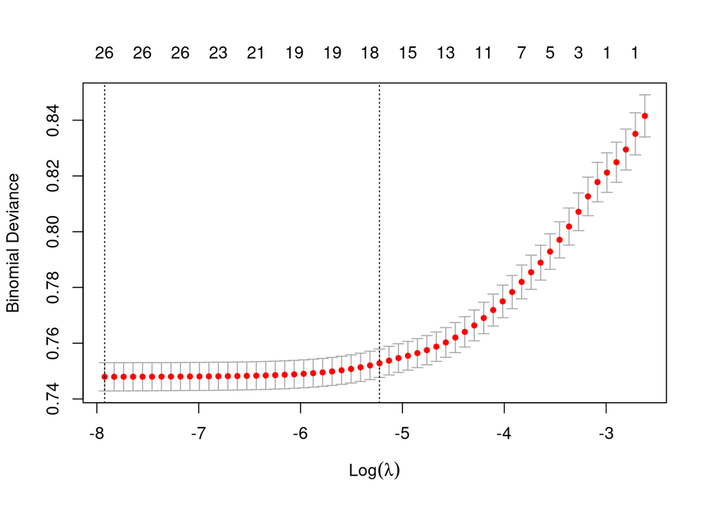

```r
plot(cv_model)
```

```r
# find the coefficients of the best lasso model
lasso_model <- glmnet(x, y, alpha = 1,
                      lambda = best_lambda, family = "binomial")
coef(lasso_model)
```

```
## 28 x 1 sparse Matrix of class "dgCMatrix"
##                                           s0
## (Intercept)                     15.818593553
## genderM                         -0.102853422
## age_hadm                         0.022184125
## marital_statusMARRIED           -0.026049369
## marital_statusSINGLE             0.027122327
## marital_statusWIDOWED           -0.052106406
## ethnicityASIAN                   0.167597502
## ethnicityBLACK/AFRICAN AMERICAN  .
## ethnicityHISPANIC/LATINO        -0.048852184
## ethnicityOTHER                  -0.086861892
## ethnicityUNABLE TO OBTAIN        0.362697590
## ethnicityUNKNOWN                 0.402338928
## ethnicityWHITE                  -0.160555381
## calcium                         -0.177115887
## magnesium                        0.029273647
## potassium                       -0.013319597
## chloride                        -0.071000136
## sodium                           0.050296232
## creatinine                       0.777859613
## bicarbonate                     -0.080808445
## glucose                          0.001861680
## hematocrit                      -0.020391244
## wbc                              0.009829423
## meanbp                          -0.001594728
## sbp                             -0.004570875
## temp                            -0.170882706
## resp_rate                        0.042946181
## heartrate                        0.010629698
```

3. Compare model prediction performance on the test set.

```r
### Predictive accuracy for logistic regression

# Calculate the accuracy for the logistic model
test_set2 <- test_set %>%
  select("gender", "age_hadm", "marital_status",
         "ethnicity", all_of(lab_vital_vars), "thirty_day_mort") %>%
  mutate_if(is.character, as.factor)
p_logistic <- predict(logistic_model, test_set2, type = "response")
predict_logistic <- ifelse(p_logistic > 0.5, 1, 0)
mean(predict_logistic == test_set2$thirty_day_mort)
```

```
## [1] 0.8554228
```

```r
# Calculate the AUC for the logistic model
library(pROC)
auc(test_set2$thirty_day_mort, p_logistic)
```

```
## Area under the curve: 0.7417
```

```r
### Predictive accuracy for logistic regression with lasso penalty

# Calculate the accuracy for the lasso model
x_test_lasso <- model.matrix(thirty_day_mort ~ ., test_set2)[, -1]
p_lasso <- predict(lasso_model, s = best_lambda, newx = x_test_lasso)
predict_lasso <- ifelse(p_lasso > 0.5, 1, 0)
mean(predict_lasso == test_set2$thirty_day_mort)
```

```
## [1] 0.8522246
```

```r
# Calculate the AUC for the lasso model
auc(test_set2$thirty_day_mort, c(p_lasso))
```

```
## Area under the curve: 0.742
```

*In summary, the two methods have similar accuracy and area under the curve (AUC), and I think both are OK for missing data imputation. However, here we are only using one imputed dataset, which is not a good idea. We should further impute in each sub-datasets and combine the results.*